# *Bop or Flop 2.0: Advanced ML Methods for Spotify Song Popularity Prediction*

### Abstract

In recent years it has become increasingly easy for individuals to monetise music, with digital streaming services seeing a dramatic rise in song production. Despite this, the classic industry problem remains; *can we predict if a song will be successful*? Previous work by Coake (2025) explored a quantitative solution via. semi-supervised machine learning, although this did not yield commercially viable results. In this paper, we introduce new data sources and advanced statistical techniques, including Bayesian inference, to improve the prediction of song popularity using Spotify Audio Features and beyond.

### Code Preamble

```python
import pandas as pd
import matplotlib.pyplot as plt
import numpy as np
import warnings
warnings.filterwarnings("ignore")
import ast
from sklearn.model_selection import train_test_split, RandomizedSearchCV
from sklearn.preprocessing import StandardScaler
from sklearn.linear_model import LogisticRegression
from sklearn.metrics import classification_report, accuracy_score, roc_auc_score, confusion_matrix, ConfusionMatrixDisplay, RocCurveDisplay
from imblearn.under_sampling import RandomUnderSampler
import pymc as pymc
```

## Introduction

**Case Study**

This paper is a second iteration of the case study initially stated by Coake (2025):

> "*An up-and-coming music record label receives large numbers of demo submissions from artists on a regular basis. Executives at the company are seeking a data-driven solution which automates the demo selection process; focused primarily on maximising commercial success and profitability for the record label.*"

**Aims and Objectives**

The objective is to use regression modelling to maximise both the predictive likelihood of a song being popular, and the financial risk associated with model accuracy. For continuity, we reuse the dataset collated by Pandya (2023) and modelled by Coake (2025). We also introduce a new dataset gathered by Freyberg (2023), which includes historical streaming data, to enrich the reliability of a defined popularity threshold.

Quantification of financial risk remains consistent with Coake (2025) to ensure comparability between models:

> "*Quantify the financial risk ... This is best represented by the confusion matrix of the final classification model:*
> - *True Positive: The demo is successful by both prediction and reality (+2).*
> - *False Positive: The demo is not successful in reality, but predicted so (-1).*
> - *True Negative: The demo is unsuccessful by both prediction and reality (+0).*
> - *False Negative: The demo is successful in reality, but is not predicted so (-2)."*

The key milestones for the project are:

- Train an optimal frequentist logistic regression model using all model features.
- Build a second logistic regression model with a Bayesian approach to account for uncertainty, and compare with the frequentist approach.
- Optimise both models to achieve higher true positive prediction, lower financial risk, or both, compared to the conclusions made by Coake (2025).

### Data Preparation

```python
# ** Step 1 Data Preparation Pipeline **

## Pandya dataset is used for joins, to ensure fluidity with previous research
## Freyberg dataset enhances insights

freyberg = pd.read_csv('freyberg_dataset.csv')

# Freyberg dataset will provide an aggregation of:
# 1. Total streams 2. No. of artists 3. Highest chart position
# This will join with Pandya, reducing volume but adding valuable features

# Converting artists field to Python list type
freyberg['artists'] = freyberg['artists'].apply(ast.literal_eval)
freyberg['num_artists'] = freyberg['artists'].apply(len)

# Define data processing for Freyberg dataset
def freyberg_processing(dataset):
    # Remove unnecessary fields
    v1 = dataset.drop(['date','country','artists','artist_genres',
                       'duration','explicit','name'],axis=1)

    v2 = ( v1
          .groupby('track_id', as_index=False)
          .agg({
              'streams': 'sum',    # Total streams
              'position': 'min',   # Min. Global Chart
              'num_artists': 'max' # No. artists
          })
         )

    return v2

freyberg_agg = freyberg_processing(freyberg)

# Merging with Pandya dataset
pandya = pd.read_csv('pandya_dataset.csv')
spotify_merged = pd.merge(pandya, freyberg_agg, on='track_id', how='inner')

# Re-use insights from previous research to inform data processing
    # We already know 'acousticness' and 'loudness' are correlated
    # We drop 'Unnamed: 0','artists','album_name','track_name' & 'artists'

def pre_split_processing(dataset):
    v1 = dataset.drop(['Unnamed: 0','artists','album_name','artists',
                       'track_name','acousticness','loudness'],
                        axis=1).dropna().drop_duplicates()

    v2 = v1.drop(['track_id'],axis=1)

    # Convert boolean fields to numeric
    v2 = v2.apply(lambda col: col.astype(int) if col.dtype == 'bool' else col)

    # Create a target variable for classification
    # Keep same popularity threshold (75)
    # Change popularity classifier to streams percentile
    v2['stream_pct'] = v2['streams'].rank(pct=True)*100
    v2['is_popular'] = v2['stream_pct'].apply(lambda x: 1 if x >= 75 else 0)
    v2 = v2.drop(['popularity','streams','stream_pct'], axis=1)

    return v2

# Completing the test-train-split
def data_split(dataset):
    # Eventual model features
    X = dataset.drop(['is_popular'],axis=1)
    y = dataset['is_popular']

    X_train, X_test, y_train, y_test = train_test_split(X, y, stratify = y,
                                                        test_size = 0.2,
                                                        random_state = 7)
    return X_train, X_test, y_train, y_test

spotify_clean = pre_split_processing(spotify_merged)
```

Both streaming and audio features datasets are combined on `track_id` using an inner join, creating a smaller enhanced dataset. Coake (2025) provides guidance on many data preparation steps in relation to the audio features data, which are applied to the newly merged dataset. We then define a split into 80:20 train and test groups, so that final data preparation steps sensitive to data leakage can be undertaken.

### Data Transformations

```python
# Splitting data now to avoid leakage
training_features = data_split(spotify_clean)[0]
training_target = data_split(spotify_clean)[2]
test_features = data_split(spotify_clean)[1]
test_target = data_split(spotify_clean)[3]

# Addressing class imbalance in training set
# Undersampling majority class
## Why? Not addressing inbalance and penalising class imbalance in RF tuning was ineffective
rus = RandomUnderSampler(sampling_strategy=1.0, random_state=7) # Undersample to ~50/50
trn_f_balanced, trn_t_balanced = rus.fit_resample(training_features, training_target)

imbalance = pd.DataFrame(training_target.value_counts())
imbalance['%'] = round(imbalance['count'] / imbalance['count'].sum(),4)
balance = pd.DataFrame(trn_t_balanced.value_counts())
balance['%'] = round(balance['count'] / balance['count'].sum(),4)

print('Target Variable Distribution for Initial Dataset\n',
      imbalance,'\nDataset Size: ',imbalance['count'].sum())
print('\nTarget Variable Distribution for Balanced Dataset\n',
      balance,'\nDataset Size: ',balance['count'].sum())

{'Test Data': test_target.count(),
 'Test (%)': round(test_target.count()/(test_target.count()+trn_t_balanced.count()),4),
 '(Balanced) Train Data': trn_t_balanced.count(),
 'Train (%)': round(trn_t_balanced.count()/(test_target.count()+trn_t_balanced.count()),4)}
# Initial 80/20 split altered to 66/33 split

# Use similar transformations as used in previous research
## Frequency Encoding for track_genre
## Normalise all numeric features

# Training Data Transformations
## Encoding
genre_frequency_tr = trn_f_balanced['track_genre'].value_counts()
trn_f_balanced['genre_freq'] = trn_f_balanced['track_genre'].map(genre_frequency_tr)
trn_f_balanced = trn_f_balanced.drop(['track_genre'], axis = 1)
## Scaling
scaler = StandardScaler()
trn_f_balanced = pd.DataFrame(scaler.fit_transform(trn_f_balanced),
                                 columns = trn_f_balanced.columns,
                                 index = trn_f_balanced.index)

# Test Data Transformations
## Using scalar.transform here to avoid data leakage
genre_frequency_tst = test_features['track_genre'].value_counts()
test_features['genre_freq'] = test_features['track_genre'].map(genre_frequency_tst)
test_features = test_features.drop(['track_genre'], axis = 1)
test_features = pd.DataFrame(scaler.transform(test_features),
                                 columns = test_features.columns,
                                 index = test_features.index)
```

```
Target Variable Distribution for Initial Dataset
             count       %
is_popular
0            3986  0.7498
1            1330  0.2502
Dataset Size:  5316

Target Variable Distribution for Balanced Dataset
             count    %
is_popular
0            1330  0.5
1            1330  0.5
Dataset Size:  2660
```

When reflecting on the outcomes of previous research, Coake (2025) states:

> "*Class imbalance must be addressed robustly to avoid the level of overfitting seen in the model.*"

Analysing the target variable for training data shows ~75% of data points are attributed to 'not popular', highlighting the same class imbalance issue. To mitigate this concern with new modelling techniques, we undersample the majority class (in training data only). Lastly, we encode the categorical feature `track_genre` and normalise all data across both train and test groups.

## Frequentist Logistic Regression

### Rationale

For standard (frequentist) logistic regression, we build the model as $$p(y_i|X,\beta)=\phi(z),$$ where $y$ is the target variable, $X$ is the model features, $\beta$ is the feature coefficients, $z=\beta_0+\beta_1x_1 + ...+\beta_nx_n$ is the regression line, and $\phi = \frac{1}{1+e^{-z}}$ is the sigmoid (logistic) function.

We then maximise the likelihood function to estimate the (one) most optimal parameter $\beta$, opening up the ability to make informed predictions.

**Why use Logistic Regression?**

Coake (2025) uses a Random Forest classifier for song popularity prediction. This is a reasonable approach, however decision-based models are highly algorithmic and as such can be prone to overfitting. Conversely, logistic regression is a probabilistic model with a strong statistical foundation in its approach. Not only can it classify the target (song popularity), but it also provides a clear understanding of model features with the strongest effects; much deeper insights than the standard 'bop or flop' outcome.

### Model Build and Optimisation

```python
freq_logreg = LogisticRegression()

# Define hyperparameters to test
hyperparams = {
    # Regularisation for overfitting
    'penalty': ['none','l1','l2','elasticnet'],
    'C': [0.01,0.1,1,10],
    # Convergence of optimisation solvers
    'solver': ['liblinear','sag','saga'],
    'max_iter': [100, 200, 500],
}

# Run logistic regression under all hyperparameters
# Using RandomizedSearchCV for computational efficiency
cross_validation = RandomizedSearchCV(estimator = freq_logreg, param_distributions = hyperparams,
                                      n_iter = 5, n_jobs = -1, scoring = 'roc_auc', random_state = 13)

cross_validation.fit(trn_f_balanced,trn_t_balanced)
print(f"Best Parameters: {cross_validation.best_params_}\nBest ROC/AUC Score: {round(cross_validation.best_score_,4)}")
```

```
Best Parameters: {'solver': 'saga', 'penalty': 'l1', 'max_iter': 200, 'C': 10}
Best ROC/AUC Score: 0.9306
```

```python
# Results are highly indicative of overfitting
# Verification of overfitting
## WOW - not overfitting!
test_preds = cross_validation.best_estimator_.predict_proba(test_features)[:, 1]
print(f"ROC/AUC Score on Test Data: {round(roc_auc_score(test_target,test_preds),4)}")
```

```
ROC/AUC Score on Test Data: 0.9137
```

We initiate the model using the `scikit-learn` library. To ensure we find an optimal solution, we perform cross-validation across a number of different hyperparameters:

- `penalty`,`C`: Parameters which control the type and strength of regularisation.
- `solver`,`max_iter`: Parameters which control the type of optimisation algorithm used to form the regression line, and the number of iterations to ensure convergence.

Given a key objective is to maximise the number of true positive events, we use ROC/AUC as the scoring target. Understanding the model's ability to accurately distinguish between each class is crucial to optimising both the number of true positive events and the net financial risk. Using the most optimal hyperparameters as determined by cross-validation, we obtain an ROC/AUC score of 0.93. Given 1 would indicate a 'perfect' model, this does warn of potential overfitting if the ROC/AUC value against unseen data varies significantly. However, a subsequent score of 0.91 against test data suggests otherwise; the model generalises well.

### Model Coefficients

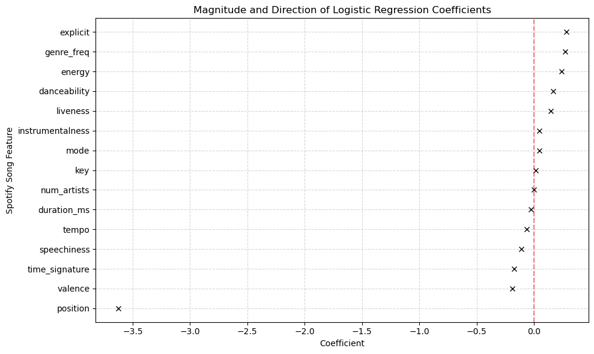

```python
# Investigate which features have strong effects
coefficients = pd.DataFrame({
    'feature': trn_f_balanced.columns,
    'coef': cross_validation.best_estimator_.coef_[0]
})

# Sort coefficients for better visualisation
coefficients_sorted = coefficients.sort_values(by = 'coef')
y_axis = np.arange(len(coefficients_sorted))

plt.figure(figsize=(10,6))

for i, row in enumerate(coefficients_sorted.itertuples(index=False)):
    plt.plot(row.coef, i, 'x', color = 'black')

plt.yticks(y_axis, coefficients_sorted['feature'])
plt.ylabel('Spotify Song Feature')
plt.xlabel('Coefficient')
plt.title('Magnitude and Direction of Logistic Regression Coefficients')
plt.grid(axis='x', linestyle='--', alpha=0.5)
plt.grid(axis='y', linestyle='--', alpha=0.5)
plt.axvline(x=0, linestyle='--', alpha=0.5, color='red')
plt.tight_layout()
plt.show()
```

**What features have strong effects?**

One of the best advantages of probabilistic modelling is the ability to see understand the finer details of a complex, multi-dimesional problem. In addition to a song's popularity, we can generally suggest (in order of effect):

*A song has a higher probability of being popular when...*

- ... it contains more explicit lyrics.
- ... it falls into a more common genre category.
- ... audio features indicate a song is more energetic, danceable and lively.

*A song has a* *much** lower probability of being popular when...*

- ... its lowest global chart position is higher. This is an expected outcome which also highlights the statistical significance of data collated by Freyberg (2023).

### Predictive Performance

```python
# Understand baseline performance via. confusion matrix
frequentist_confusion = confusion_matrix(test_target, (test_preds >= 0.5).astype(int))
true_neg = frequentist_confusion[0,0]
true_pos = frequentist_confusion[1,1]
false_neg = frequentist_confusion[1,0]
false_pos = frequentist_confusion[0,1]
financial_risk = (0*true_neg)+(2*true_pos)+(-2*false_neg)+(-1*false_pos)

{
    'True Positives': true_pos,
    'True Negatives': true_neg,
    'False Positives': false_pos,
    'False Negatives': false_neg,
    'Financial Risk': financial_risk
}
```

[output not shown]

```python
# Can we optimise the confusion matrix????
# Optimisation by iteration
optimisation = []

for i in np.linspace(0, 1, 100000):
    bin_test_preds2 = (test_preds >= i).astype(int)
    frequentist_confusion = confusion_matrix(test_target, bin_test_preds2)

    true_neg = frequentist_confusion[0,0]
    true_pos = frequentist_confusion[1,1]
    false_neg = frequentist_confusion[1,0]
    false_pos = frequentist_confusion[0,1]
    financial_risk = (0*true_neg)+(2*true_pos)+(-2*false_neg)+(-1*false_pos)

    optimisation.append({
        'logistic_threshold':i,
        'true_negatives':true_neg,
        'true_positives':true_pos,
        'false_negatives':false_neg,
        'false_positives':false_pos,
        'financial_risk':financial_risk
    })

optimisation = pd.DataFrame(optimisation)
optimisation_sorted = optimisation.sort_values(['financial_risk','true_positives'],ascending=False)
optimisation_sorted.head(10)
```

|  | logistic_threshold | true_negatives | true_positives | false_negatives | false_positives | financial_risk |
| --- | --- | --- | --- | --- | --- | --- |
| 54976 | 0.549765 | 804 | 300 | 32 | 193 | 343 |
| 54977 | 0.549775 | 804 | 300 | 32 | 193 | 343 |
| 54978 | 0.549785 | 804 | 300 | 32 | 193 | 343 |
| 54979 | 0.549795 | 804 | 300 | 32 | 193 | 343 |
| 54980 | 0.549805 | 804 | 300 | 32 | 193 | 343 |
| 54981 | 0.549815 | 804 | 300 | 32 | 193 | 343 |
| 54982 | 0.549825 | 804 | 300 | 32 | 193 | 343 |
| 54983 | 0.549835 | 804 | 300 | 32 | 193 | 343 |
| 54984 | 0.549845 | 804 | 300 | 32 | 193 | 343 |
| 54985 | 0.549855 | 804 | 300 | 32 | 193 | 343 |

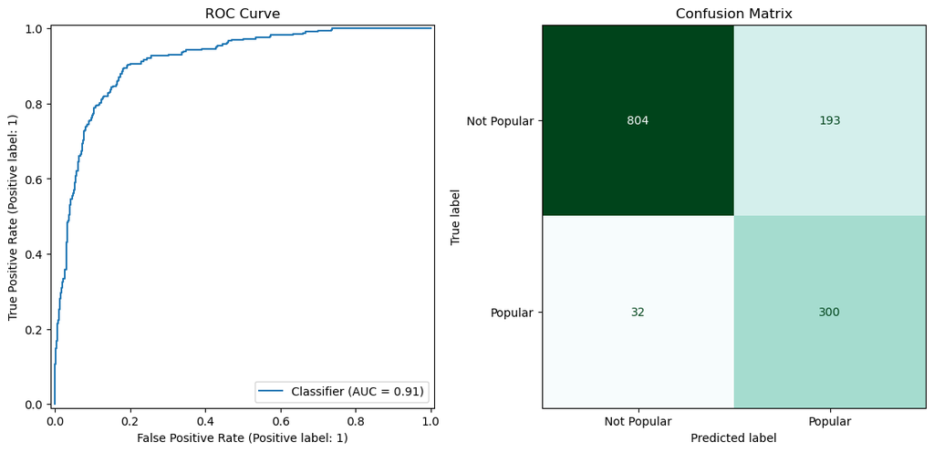

```python
# Final Optimised Output
# ROC/AUC and Confusion Matrix
fig, axes = plt.subplots(1, 2, figsize=(14, 6))

## ROC Curve + ROC/AUC Score
RocCurveDisplay.from_predictions(test_target,test_preds,ax=axes[0])
axes[0].set_title("ROC Curve")

# Convert logistic predictions to binary outcome
## Necessary to compute confusion matrix
## -- Can be optimised --
bin_test_preds = (test_preds >= optimisation_sorted['logistic_threshold'].iloc[0]).astype(int)
frequentist_confusion = confusion_matrix(test_target, bin_test_preds)

ConfusionMatrixDisplay(confusion_matrix = frequentist_confusion,
                       display_labels=['Not Popular', 'Popular'],
                      ).plot(ax=axes[1], cmap = 'BuGn', colorbar = False)
axes[1].set_title('Confusion Matrix')
```

## Bayesian Logistic Regression

### Rationale

For Bayesian logistic regression, we treat each $\beta$ from $z$ as random variables to find the probability of each possible (optimal) $\beta$. Derived from Bayes' Theorem of conditional probability, we formulate predictions as $$p(\beta_j|X,y_i)\propto p(y_i|X,\beta_j)\times p(\beta_j).$$

This births three unique probability distributions:

[output not shown]

**Why Bayesian over the Frequentist approach?**

Bayesian inference adds an extra layer of details over standard statistical methods by accounting for uncertainty. Using a frequentist logstic regression model we can obtain insight on the magnitude and direction of a feature's importance on classification. A Bayesian logistic regression model will output magnitude and direction in addition to the *credible interval*; the probability of a coefficient value lying between a given interval. Another benefit of the Bayesian approach is the concept of prior distributions. We can use previous knowledge and/or test hypotheses to establish a useful baseline for modelling.

```python
with pymc.Model() as bay_logreg:
    # Prior: Beta ~ N(0,1)
    # Prior based on normalisation + outputs of frequentist model
    # 15 features / beta coefficients as per shape
    beta = pymc.Normal("beta", mu=0, sigma=1, shape=trn_f_balanced.shape[1])
    intercept = pymc.Normal("intercept", mu=0, sigma=1)

    # Regression line
    # Dot product to form B0 + B1X1 + B2X2 + ...
    line = intercept + pymc.math.dot(trn_f_balanced, beta)

    # Likelihood: Binary Target so Bernoulli distribution
    y_obs = pymc.Bernoulli("y_obs", logit_p=line, observed=trn_t_balanced)
```

### Laplace Approximation

In order to make predictions and evaluate model performance, we need to define the posterior distribution via. approximation. There are multiple ways to do this, however we proceed with the **Laplace approximation**.

We have a Normal prior, $\beta_j \sim \mathcal{N}(0,1)$, so the posterior distribution is approximated at its local maximum, given by a combination of the prior and log-likelihood function; we know this to be Bernoulli.

The likelihood function, $$p(y_i|X,\beta_j) = \phi(z) = \frac{1}{1+e^{-(\beta_0+\beta_1x_1+...)}},$$

has the following Bernoulli log-likelihood for all observations $y_i$ : $$ln\: p(y_i|X,\beta_j) = \sum_{i=1}^{n}\: [\: y_i\: ln\: \phi(z) + (1-y_i)\:ln\:(1-\phi(z))\:].$$

We now maximise the posterior using the *maximum a posteriori* (MAP) estimate:

$$ MAP = \arg \max_{\beta_j}\: [\: p(\beta_j|X,y_i) \:] = \arg \max_{\beta_j}\: [\: ln\:p(y_i|X,\beta_j) + ln\:p(\beta_j) \:]$$$$ = \arg \max_{\beta_j}\: \sum_{i=1}^{n}\: [\: y_i\: ln\: \phi(z) + (1-y_i)\:ln\:(1-\phi(z))\:] - \frac{1}{2\sigma^2}||\beta||^2,$$

where $- \frac{1}{2\sigma^2}||\beta||^2$ is the log-likelihood of the Normal prior.

```python
# Find and display maximum a posteriori
map_estimate = pymc.find_MAP(model = bay_logreg)
print('Posterior Estimates\n')
beta = 0
for i in range(len(map_estimate['beta'])):
    if beta == 0:
        print(f"beta_{beta} (intercept) = {map_estimate['intercept']} ")
    else:
        print(f"beta_{beta+1} = {map_estimate['beta'][beta]}")
    beta = beta + 1
```

```
Output()
```

```
Posterior Estimates

beta_0 (intercept) = -1.0434255403738757
beta_2 = 0.2762387561940392
beta_3 = 0.17094169904582354
beta_4 = 0.23687324156705222
beta_5 = 0.014998347824210088
beta_6 = 0.04772933969372736
beta_7 = -0.10700545694086945
beta_8 = 0.0467318594252274
beta_9 = 0.14060329888210976
beta_10 = -0.18564014349533695
beta_11 = -0.06328176225973266
beta_12 = -0.1707293954815009
beta_13 = -3.5216034724035996
beta_14 = 0.004034143881939913
beta_15 = 0.2767582920601789
```

### Posterior Coefficients

Given we assume the distribution has only one maximum, we can class the collection of points above as the **mean** of the posterior distribution. In order to form an approximation for the (Normal) posterior distribution we need to find the **covariance**; we find this using a *Hessian Matrix*. These are special matrices used primarily to mathematically determine local minima and maxima for a multivariate equation. In a statistical context, the inverse of a Hessian Matrix is equal to the covariance (matrix) of a multivariate dataset. We omit the mathematical proof as it is not relevant to this task.

With mean and covariance defined we can build an approximated Normal posterior distribution, which can then be used for prediction.

```python
# Mean column vector
mean = np.concatenate([[map_estimate["intercept"]], map_estimate["beta"]])

# Create covariance matrix
hessian = pymc.find_hessian(map_estimate, model = bay_logreg)
covar = np.linalg.inv(hessian)

# Generate the posterior distribution
## Create 1000 samples of possible optimal 15-coefficient sets
pstr_dist = np.random.multivariate_normal(mean, covar, size=1000)
```

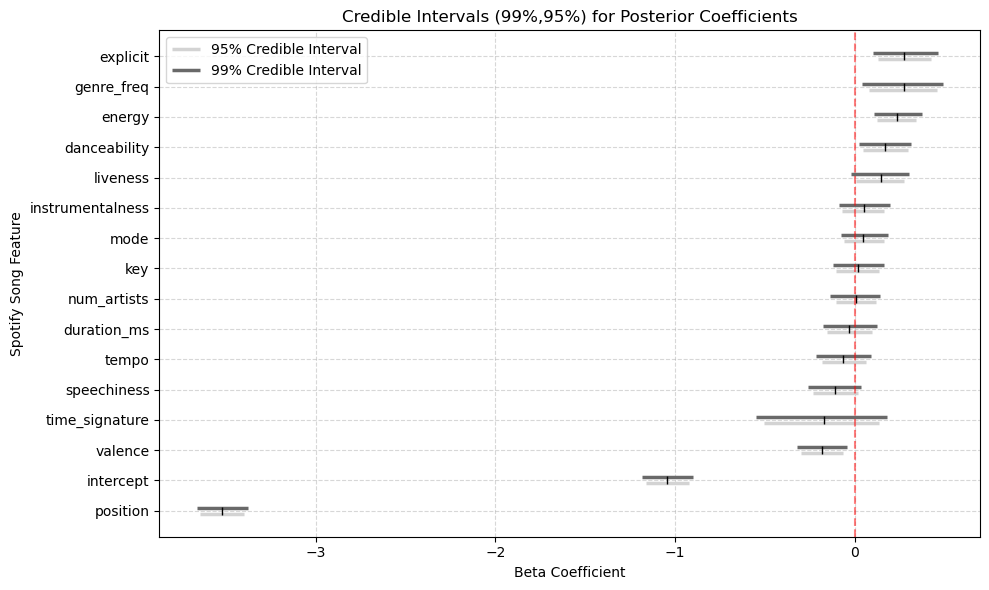

```python
# Charts
## Plot coefficients (tied to feature name) with credible intervals
features = ['intercept'] + list(trn_f_balanced.columns.values)
pstr_samples = pd.DataFrame(pstr_dist, columns=features)
coef_credible = pd.DataFrame({
    'feature': features,
    'q2': pstr_samples.median(),
    'q1_95': pstr_samples.quantile(0.025),
    'q3_95': pstr_samples.quantile(0.975),
    'q1_99': pstr_samples.quantile(0.01),
    'q3_99': pstr_samples.quantile(0.99)
})
coef_credible = coef_credible.sort_values(by = 'q2', ascending = True)
features = coef_credible['feature']

plt.figure(figsize = (10,6))
## Create a grouped boxplot style chart split by feature and CI
y_axis = np.arange(len(features))
for i, feature in enumerate(features):
    # 95% credible interval
    plt.hlines(y = i - 0.1,   # Force space between plots
               xmin = coef_credible['q1_95'][i],
               xmax = coef_credible['q3_95'][i],
               color = 'lightgray', linewidth = 2.5,
               label = '95% Credible Interval' if i == 1 else "")
    # 99% credible interval
    plt.hlines(y = i + 0.1,   # Force space between plots
               xmin = coef_credible['q1_99'][i],
               xmax = coef_credible['q3_99'][i],
               color = 'dimgray', linewidth = 2.5,
               label = '99% Credible Interval' if i == 1 else "")
    plt.plot(coef_credible['q2'][i], i,
             '|', color = 'black')

plt.yticks(y_axis, features)
plt.ylabel('Spotify Song Feature')
plt.xlabel('Beta Coefficient')
plt.title('Credible Intervals (99%,95%) for Posterior Coefficients')
plt.grid(axis = 'x', linestyle = '--', alpha = 0.5)
plt.grid(axis = 'y', linestyle = '--', alpha = 0.5)
plt.axvline(x = 0, linestyle = '--', alpha = 0.5, color = 'red')
plt.legend(loc = 'upper left')
plt.tight_layout()
plt.show()
```

The posterior coefficient plot shows, as expected, a similar theme to the frequentist approach, although there are some key differences when accounting for credible intervals:

- A song has a higher probability of being popular when it falls into a more common genre category, *however* there is a high level of uncertainty in this value. In fact, there is a possibility that the effect of `genre_freq` is minimal.
- There is such a high level of uncertainty in `time_signature` that it is possible this audio feature could have either a large positive or negative effect.

### Predictive Performance

As we now have a posterior distribution $p(\beta_j|X,y_i) \approx \mathcal{N}(\mu,\sigma^2)$, we need to find the *posterior predictive distribution* in order to predict new data points. Gelman (2013) states that to make predictions $\breve{y}$ given observations $(y,\theta)$, the posterior predictive distribution is given by

$$p(\breve{y}|y) = \int p(\breve{y}|\theta)\: p(\theta|y)\: d\theta.$$

For the Spotify dataset, we wish to predict new data points $X_{new}$ (predict a song is popular, $y=1$), based on known observations. Therefore the posterior predictive distribution is

$$p(y_i=1|X_{new},X,y_i) = \int p(y=1|X_{new},\beta_j)\: p(\beta_j|X,y_i)\: d\beta. $$

This is equivalent to the likelihood function and the posterior distribution, so this can be simplified to

$$p(y_i=1|X_{new},X,y_i) = \int \phi(z)\: \mathcal{N}(\mu,\sigma^2)\: d\beta. $$

Unfortunately, this integral is not calculable and another approximation is required. Similar to the rationale of conducting the Laplace approximation for the posterior distribution, there are many different approaches. We proceed with an analytical approximation shown in texts such as Bishop (2006) which reduces the posterior predictive distribution to

$$\int \phi(z)\: \mathcal{N}(\mu,\sigma^2)\: d\beta \approx \phi \left( \frac{\mu}{\sqrt{1+\frac{\pi^2}{8}\sigma}} \right).$$

```python
# Predictions on test data
test_features_intercept = np.column_stack((np.ones(test_features.shape[0]), test_features))
mean_test = test_features_intercept.mean()
covar_test = np.sum(test_features_intercept @ covar * test_features_intercept, axis=1)

# Create logistic predictions based on posterior predictive distribution
test_preds = 1 / (1 + np.exp(-(mean_test/(np.sqrt(1+(covar_test*((np.pi**2)/8)))))))
```

```python
bayesian_confusion = confusion_matrix(test_target, (test_preds >= 0.5).astype(int))
true_neg = bayesian_confusion[0,0]
true_pos = bayesian_confusion[1,1]
false_neg = bayesian_confusion[1,0]
false_pos = bayesian_confusion[0,1]
financial_risk = (0*true_neg)+(2*true_pos)+(-2*false_neg)+(-1*false_pos)

{
    'True Positives': true_pos,
    'True Negatives': true_neg,
    'False Positives': false_pos,
    'False Negatives': false_neg,
    'Financial Risk': financial_risk
}
```

```
{'True Positives': 332,
 'True Negatives': 0,
 'False Positives': 997,
 'False Negatives': 0,
 'Financial Risk': -333}
```

```python
# Can we optimise the confusion matrix????
# Optimisation by iteration
optimisation = []

for i in np.linspace(0, 1, 100000):
    bin_test_preds2 = (test_preds >= i).astype(int)
    bayesian_confusion = confusion_matrix(test_target, bin_test_preds2)

    true_neg = bayesian_confusion[0,0]
    true_pos = bayesian_confusion[1,1]
    false_neg = bayesian_confusion[1,0]
    false_pos = bayesian_confusion[0,1]
    financial_risk = (0*true_neg)+(2*true_pos)+(-2*false_neg)+(-1*false_pos)

    optimisation.append({
        'logistic_threshold':i,
        'true_negatives':true_neg,
        'true_positives':true_pos,
        'false_negatives':false_neg,
        'false_positives':false_pos,
        'financial_risk':financial_risk
    })

optimisation = pd.DataFrame(optimisation)
optimisation_sorted = optimisation.sort_values(['financial_risk','true_positives'],ascending=False)
optimisation_sorted.head(10)
```

|  | logistic_threshold | true_negatives | true_positives | false_negatives | false_positives | financial_risk |
| --- | --- | --- | --- | --- | --- | --- |
| 50847 | 0.508475 | 134 | 307 | 25 | 863 | -299 |
| 50846 | 0.508465 | 132 | 307 | 25 | 865 | -301 |
| 50848 | 0.508485 | 135 | 306 | 26 | 862 | -302 |
| 50845 | 0.508455 | 130 | 307 | 25 | 867 | -303 |
| 50851 | 0.508515 | 142 | 304 | 28 | 855 | -303 |
| 50849 | 0.508495 | 137 | 305 | 27 | 860 | -304 |
| 50838 | 0.508385 | 120 | 309 | 23 | 877 | -305 |
| 50839 | 0.508395 | 120 | 309 | 23 | 877 | -305 |
| 50844 | 0.508445 | 128 | 307 | 25 | 869 | -305 |
| 50852 | 0.508525 | 144 | 303 | 29 | 853 | -305 |

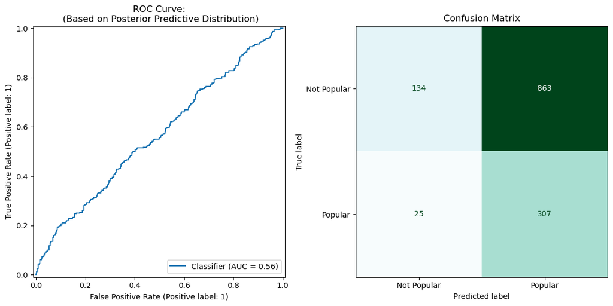

```python
# Optimised ROC/AUC and Confusion Matrix
fig, axes = plt.subplots(1, 2, figsize=(14, 6))

RocCurveDisplay.from_predictions(test_target,test_preds,ax=axes[0])
axes[0].set_title(f"ROC Curve:\n (Based on Posterior Predictive Distribution)")

bin_test_preds = (test_preds >= optimisation_sorted['logistic_threshold'].iloc[0]).astype(int)
bayesian_confusion = confusion_matrix(test_target, bin_test_preds)

ConfusionMatrixDisplay(confusion_matrix = bayesian_confusion,
                       display_labels=['Not Popular', 'Popular'],
                      ).plot(ax=axes[1], cmap = 'BuGn', colorbar = False)
axes[1].set_title('Confusion Matrix')
```

## Conclusion

**Which model performs best?**

[output not shown]

In conclusion, we recommend, at least, that logistic regression is the model of choice for song prediction. However, individuals interested in the outputs of this research should be consulted to decide which of the logistic regression models is optimal, as both offer unique advantages.

- The **Bayesian** model is able to predict the highest number of popular songs. However, it carries the caveat that blindly following all outputs of this model is likely to provide net financial loss.
- The **Frequentist** model provides an excellent balance of high predictive accuracy and net financial profit. However, this model is unable to predict as many popular songs as the Bayesian approach. It also carries the caveat that there will always be a proportion of predictions that class as 'missed opportunities'; a song is successful but not predicted so. The Bayesian model has the ability to eliminate this entirely.

## Acknowledgments

The author acknowledges the use of ChatGPT-5 (OpenAI, https://chat.openai.com) as an assistive role for planning and simplifying advanced modelling processes.

The author also acknowledges extended use of the following Python library documentation:

- `PyMC` (https://www.pymc.io/projects/docs) for the simplification of Bayesian modelling.
- `NumPy` (https://numpy.org/doc/2.3/reference) for understanding mathematical computation and probability distributions in code.

All analysis, interpretations and conclusions have been conducted by the author.

## References

Pandya, M. 2023. Spotify Tracks Dataset. *Hugging Face*. [Online]. [Accessed 11 October 2025]. Available from: https://huggingface.co/datasets/maharshipandya/spotify-tracks-dataset

Freyberg, J. 2023. Spotify tracks chart dataset (2014-2022). *Kaggle*. [Online]. [Accessed 12 October 2025]. Available from: https://www.kaggle.com/datasets/jfreyberg/spotify-chart-data

Coake, B.J. 2025. *Bop or Flop? A Semi-Supervised Approach to Predicting Song Popularity via Spotify Audio Features*. Unpublished.

Gelman, A. 2013. *Bayesian Data Analysis* [Online]. pp.6-11. [Accessed 17 October 2025]. CRC Press. Available from: https://doi.org/10.1201/b16018

Bishop, C.M. 2006. *Pattern recognition and machine learning*. New York: Springer.